# Ammonia Oxidizers Growth Model

Alex Kanellopoulos

2024-08-22

Brief description: This is a script that models the growth of routine cultures of ammonia oxidising microorganisms maintained in our lab. It uses the produced nitrite concentrations in order to obtain growth curves for successive generations and a single sigmoidal curve model to fit those data and produce a single growth curve equation. Finally, it can also calculate the specific maximum growth rate (μ) based on the linear part of a semi - logarithmic nitrite vs time curve.

Step 1: Let’s see all the necessary packages needed for the analysis and load them. If they are not installed, we will install them first.

```r
# Here we store the necessary packages in the necessary_packages variable
necessary_packages <- c("readxl","dplyr","ggplot2","sicegar","patchwork","viridis","scales","SciViews")

# Here we check if the necessary packages are installed. If not, R installs them
if (!requireNamespace(necessary_packages, quietly = TRUE)) {
  install.packages(necessary_packages)
}

# Here, for every package included in the necessary_packages variable, R will load it. The character.only = TRUE ensures that library() will try to interpret the package names as characters (as it needs for it to work)
for (package in necessary_packages) {
  library(package, character.only = TRUE)
}
```

Step 2: We will load the data. The data need to be in a data.xlsx file as presented, with the following data in separate columns: Time (in hours), Biological Replicate (optional), Generation, Nitrite (in μM), Mean (of Nitrite between biological replicates), Standard Deviation (of Nitrite between biological replicates), CV% (of Nitrite between biological replicates, optional)

See this .txt format only as an example:

```
## # A tibble: 12 × 7
##    `Time (hours)` Replicate Generation `[Nitrite] (uM)`  Mean `St. Dev` `CV%`
##             <dbl> <chr>     <chr>                 <dbl> <dbl>     <dbl> <dbl>
##  1             20 NCOM (1)  1st                    94.6   NA      NA    NA
##  2             20 NCOM (2)  1st                    99.3  100.      4.72  4.72
##  3             20 NCOM (3)  1st                   106.    NA      NA    NA
##  4             45 NCOM (1)  1st                   227.    NA      NA    NA
##  5             45 NCOM (2)  1st                   258    268.     37.8  14.1
##  6             45 NCOM (3)  1st                   318.    NA      NA    NA
##  7             89 NCOM (1)  1st                  1083     NA      NA    NA
##  8             89 NCOM (2)  1st                  1259   1226     106.    8.64
##  9             89 NCOM (3)  1st                  1336     NA      NA    NA
## 10            115 NCOM (1)  1st                  1812     NA      NA    NA
## 11            115 NCOM (2)  1st                  1931   1910      73.0   3.82
## 12            115 NCOM (3)  1st                  1987     NA      NA    NA
```

So let’s import the data

```r
# Here, we create an R data frame named data_routine with the data of the data.xlsx file. Here, we take the data from the first sheet of the file, from cells B1 to H268 and we keep the names of the columns (first row)
library(readxl)
data_routine <- read_excel("data.xlsx", sheet = 1, range = "B1:H268", col_names = TRUE)
# We can change the names of the columns to more R-friendly names
names(data_routine) <- c("Time", "Replicate", "Generation", "Nitrite", "Mean", "St.Dev", "CV%")
#We keep only the rows that contain a Nitrite value (thus removing rows that are left blank to make life easier when viewing the .xlsx file)
data_routine <- filter(data_routine, !is.na(Nitrite))
#Let's view the data
glimpse(data_routine)
```

```
## Rows: 249
## Columns: 7
## $ Time       <dbl> 20, 20, 20, 45, 45, 45, 89, 89, 89, 115, 115, 115, 138, 138…
## $ Replicate  <chr> "NCOM (1)", "NCOM (2)", "NCOM (3)", "NCOM (1)", "NCOM (2)",…
## $ Generation <chr> "1st", "1st", "1st", "1st", "1st", "1st", "1st", "1st", "1s…
## $ Nitrite    <dbl> 94.60, 99.26, 106.10, 226.80, 258.00, 317.80, 1083.00, 1259…
## $ Mean       <dbl> NA, 99.98667, NA, NA, 267.53333, NA, NA, 1226.00000, NA, NA…
## $ St.Dev     <dbl> NA, 4.7228899, NA, NA, 37.7572362, NA, NA, 105.8898799, NA,…
## $ `CV%`      <dbl> NA, 4.7235197, NA, NA, 14.1130960, NA, NA, 8.6370212, NA, N…
```

Step 3: Here we want to produce an activity line plot for the consecutive generations of our ammonia oxidiser cultures.

```r
# Let's first remove any rows with NAs from the dataset, because it will clash with the lineplot and the lines will not appear
data_routine_line_plot <- filter(data_routine, !is.na(Mean))
# We will use ggplot for the lineplot generation
library(ggplot2)
library(viridis)
activity_line_plot <- ggplot(data_routine_line_plot, aes(x = Time, y = Mean)) +
  geom_point(aes(colour = Generation)) +
  theme_light() +
  labs(x = "Time (Hours)", y = "[Nitrite] (μM)") +
  theme(axis.title = element_text(size = 28), axis.text = element_text(size = 24), legend.text = element_text(size = 20), legend.title = element_text(size = 20)) +
  scale_y_continuous(breaks = seq(0,max(data_routine_line_plot$Mean), by = max(data_routine_line_plot$Mean)/5)) + ylim(0,max(data_routine_line_plot$Mean)) +
  scale_color_viridis(option = "D", discrete = T)
activity_line_plot <- activity_line_plot +
  geom_errorbar(aes(ymin = Mean - St.Dev, ymax = Mean + St.Dev, width = 0.2, colour = Generation)) +
  geom_line(data = data_routine_line_plot, aes(x = Time, y = Mean, colour = Generation), linewidth = 0.6)

cairo_pdf("Activity_Lineplot.pdf", height = 10, width = 10)
print(activity_line_plot)
dev.off()
```

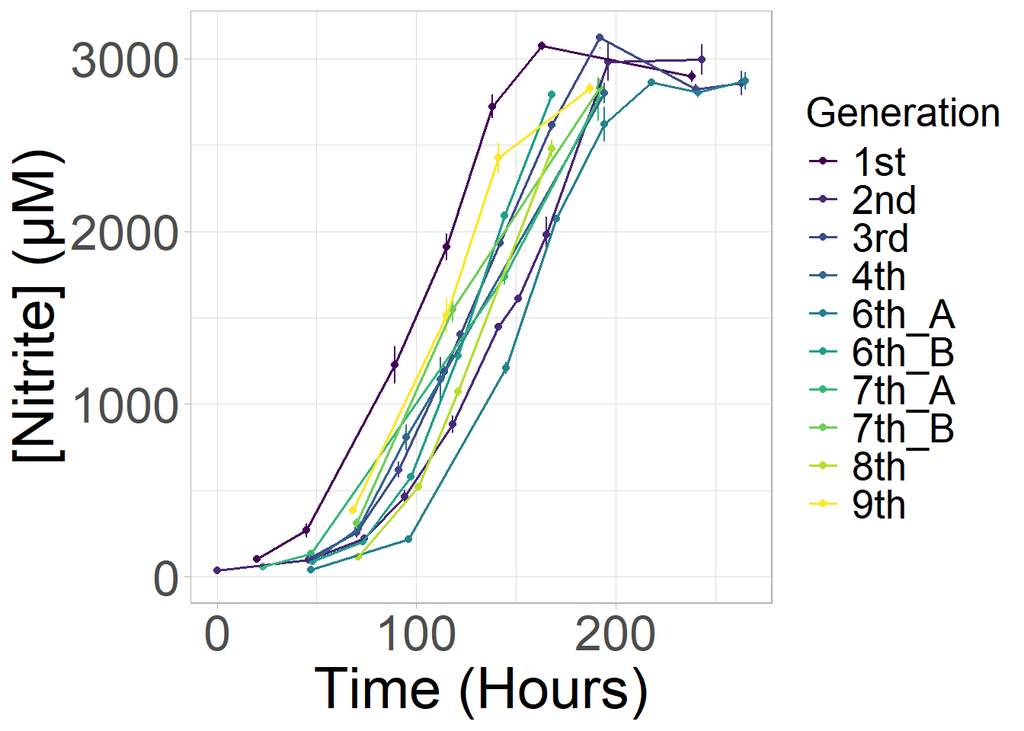

```r
activity_line_plot
```

```r
# You can find the .pdf file in your folder!
```

Step 4: We can use a single - sigmoidal model and fit our data in this in order to obtain an equation describing the culture growth (in this case synonymous with nitrite production) over time

```r
# Let's prepare the data
# We want to keep only the 2 columns containing the Time and Nitrite values
data_model <- data.frame(data_routine$Time, data_routine$Nitrite)
# We change the names of the two columns to names required by the "sicegar" package
names(data_model) <- c("time", "intensity")
glimpse(data_model)
```

```
## Rows: 249
## Columns: 2
## $ time      <dbl> 20, 20, 20, 45, 45, 45, 89, 89, 89, 115, 115, 115, 138, 138,…
## $ intensity <dbl> 94.60, 99.26, 106.10, 226.80, 258.00, 317.80, 1083.00, 1259.…
```

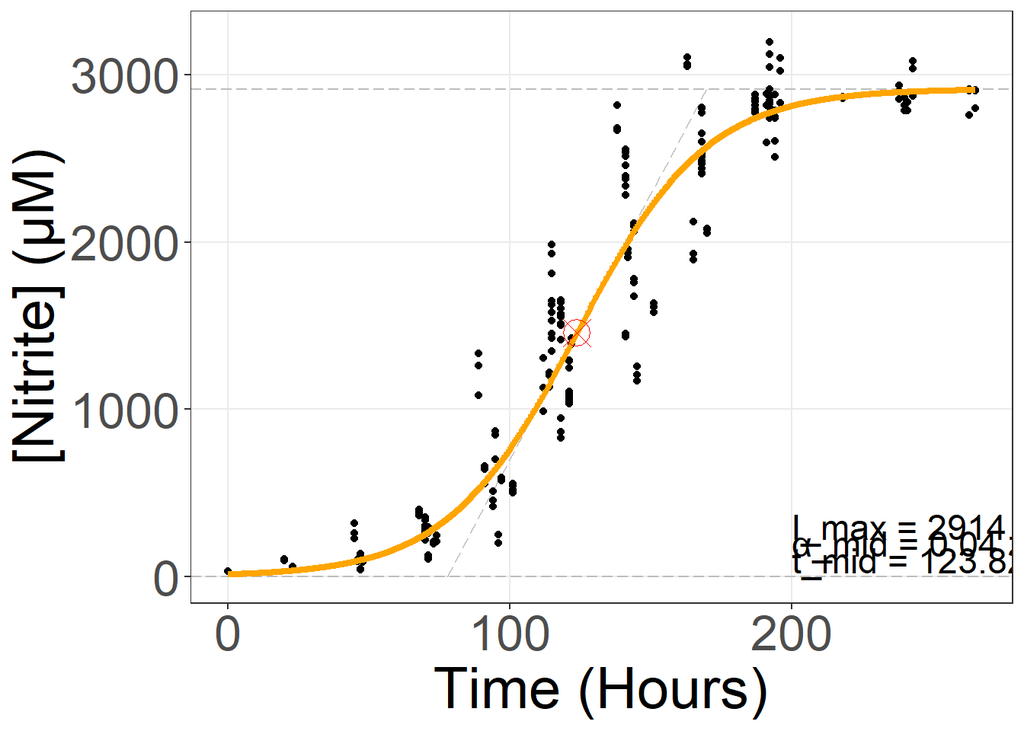

```r
# Let's give the command to generate the model
library(sicegar)
fitObj_sm <- fitAndCategorize(dataInput = data_model,
                              threshold_t0_max_int = 100,
                              threshold_minimum_for_intensity_maximum = 0.02)
# And we can prepare a plot of the sigmoidal curve
growth_sigmoid_model_plot <- figureModelCurves(dataInput = fitObj_sm$normalizedInput,
                                               sigmoidalFitVector = fitObj_sm$sigmoidalModel,
                                               showParameterRelatedLines = T)
growth_sigmoid_model_plot <- growth_sigmoid_model_plot +
  labs(x = "Time (Hours)", y = "[Nitrite] (μM)") +
  theme(axis.title = element_text(size = 28), axis.text = element_text(size = 24), legend.text = element_text(size = 20), legend.title = element_text(size = 20)) +
  scale_y_continuous(breaks = seq(0,max(data_routine_line_plot$Mean + 100), by = max(data_routine_line_plot$Mean)/5)) + ylim(0,max(data_routine_line_plot$Mean) + 100) +
  annotate("text", x = 200, y = 300, label = paste("I_max =", round(fitObj_sm$sigmoidalModel$maximum_Estimate, 2)), size = 6, hjust = 0) +
  annotate("text", x = 200, y = 200, label = paste("α_mid =", round(fitObj_sm$sigmoidalModel$slopeParam_Estimate, 2)), size = 6, hjust = 0) +
  annotate("text", x = 200, y = 100, label = paste("t_mid =", round(fitObj_sm$sigmoidalModel$midPoint_Estimate, 2)), size = 6, hjust = 0)

print(growth_sigmoid_model_plot)
```

Step 5: We can use the single - sigmoidal model equation to overlay the model curve with the real data. The equation we will follow is the one described in Caglar et al. (2018)

I(t) = fsig(t) = Imax / [1+exp(−a1(t−tmid))].

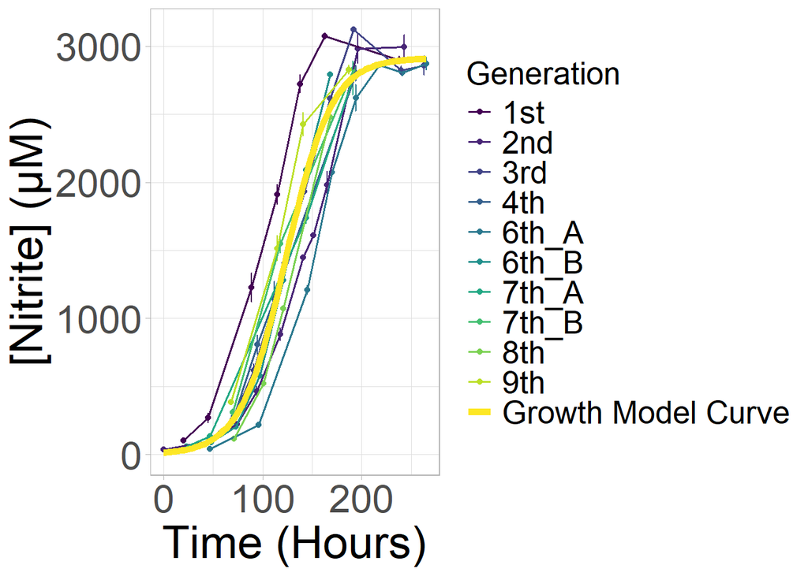

```r
# Here we obtain the parameters of the sigmoidal model, insert them in the single sigmoidal curve equation and put it as a function of time (t)
model_curve <- function(t) {fitObj_sm$sigmoidalModel$maximum_Estimate/(1+exp(-fitObj_sm$sigmoidalModel$slopeParam_Estimate*(t-fitObj_sm$sigmoidalModel$midPoint_Estimate)))}

# We can also obtain its reverse function, solving for nitrite (N) instead of time
model_curve_reverse <- function(N) {((-ln((fitObj_sm$sigmoidalModel$maximum_Estimate/N)-1)/fitObj_sm$sigmoidalModel$slopeParam_Estimate)+fitObj_sm$sigmoidalModel$midPoint_Estimate)}

# We will use the same activity plot as before but overlay the model curve
library(ggplot2)
library(viridis)
activity_line_plot_with_model <- ggplot(data_routine_line_plot, aes(x = Time, y = Mean)) +
  geom_point(aes(colour = Generation)) +
  theme_light() +
  labs(x = "Time (Hours)", y = "[Nitrite] (μM)") +
  theme(axis.title = element_text(size = 28), axis.text = element_text(size = 24), legend.text = element_text(size = 20), legend.title = element_text(size = 20)) +
  scale_y_continuous(breaks = seq(0,max(data_routine_line_plot$Mean), by = max(data_routine_line_plot$Mean)/5)) + ylim(0,max(data_routine_line_plot$Mean)) +
  scale_color_viridis(option = "D", discrete = T)

activity_line_plot_with_model <- activity_line_plot_with_model +
  geom_errorbar(aes(ymin = Mean - St.Dev, ymax = Mean + St.Dev, width = 0.2, colour = Generation)) +
  geom_line(data = data_routine_line_plot, aes(x = Time, y = Mean, colour = Generation), linewidth = 0.6) +
  stat_function(fun = model_curve, linewidth = 2, aes(colour = "Growth Model Curve"))

print(activity_line_plot_with_model)
```

```r
cairo_pdf("Activity_Lineplot_with_model.pdf", height = 10, width = 10)
print(activity_line_plot_with_model)
dev.off()
```

```r
# You can find the .pdf file in your folder!
```

Step 6: We can calculate the maximum specific growth rate from the activity data, using the approach described in Shaw et al. (2006). Briefly, we isolate the data from the exponential growth phase and we perform a semi - logarithmic transformation, using the natural logarithm (ln) to transform the nitrite values

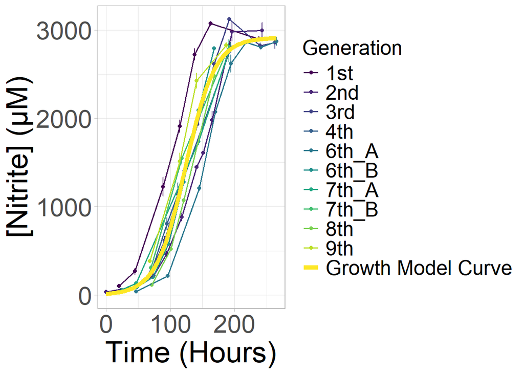

```r
# We visually assess the activity plot to pin down the exponential growth phase
print(activity_line_plot_with_model)
```

```r
# We assume that the exponential growth phase lasts from 40 h - 175 h, so we isolate these data
library(dplyr)
data_exponential <- filter(data_routine, between(Time, 40, 175))

# We transform the Nitrite values
library(SciViews)
data_exponential_ln <- mutate(data_exponential, Nitrite = ln(Nitrite))

# We will evaluate the quality of th elinear regression
# The maximum specific growth rate is congruent with the slope coefficient of the linear regression
linear_regression_report <- summary(lm(Nitrite ~ Time, data = data_exponential_ln))
μmax <- round(linear_regression_report$coefficients[2,1],3)
μmax_std_error <- round(linear_regression_report$coefficients[2,2],3)
linear_regression_report
```

```
##
## Call:
## lm(formula = Nitrite ~ Time, data = data_exponential_ln)
##
## Residuals:
##     Min      1Q  Median      3Q     Max
## -1.2290 -0.3448  0.0330  0.3487  1.1330
##
## Coefficients:
##              Estimate Std. Error t value Pr(>|t|)
## (Intercept) 3.6407225  0.1009258   36.07   <2e-16 ***
## Time        0.0272325  0.0008893   30.62   <2e-16 ***
## ---
## Signif. codes:  0 '***' 0.001 '**' 0.01 '*' 0.05 '.' 0.1 ' ' 1
##
## Residual standard error: 0.4565 on 184 degrees of freedom
## Multiple R-squared:  0.836,  Adjusted R-squared:  0.8351
## F-statistic: 937.7 on 1 and 184 DF,  p-value: < 2.2e-16
```

```r
μmax
```

```
## [1] 0.027
```

```r
μmax_std_error
```

```
## [1] 0.001
```

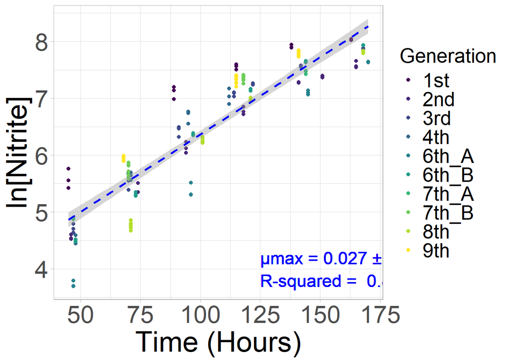

```r
# We plot the data and we will incorporate the maximum specific growth rate value in the plot
line_plot_exponential_ln <- ggplot(data_exponential_ln, aes(x = Time, y = Nitrite)) +
  theme_light() +
  geom_point(aes(colour = Generation)) +
  labs(y = "ln[Nitrite]", x = "Time (Hours)") +
  theme(axis.title = element_text(size = 28), axis.text = element_text(size = 24), legend.text = element_text(size = 20), legend.title = element_text(size = 20)) +
  scale_color_viridis(option = "D", discrete = T) +
  stat_smooth(method = "lm", col = "blue", se = TRUE, linewidth = 1, linetype = "dashed") +
  geom_text(x = 125, y = 4.2, label = paste("μmax =", μmax, "±", μmax_std_error), colour = "blue", size = 6, hjust = 0) +
  geom_text(x = 125, y = 3.80, label = paste("R-squared = ", round(linear_regression_report$adj.r.squared,2)), colour = "blue", size = 6, hjust = 0)

print(line_plot_exponential_ln)
```

```r
# Let's save the plot. cairo_pdf() had some weird behaviour, so we can use ggsave(), which usually handles fonts in ggplots better
ggsave("Maximum_growth_rate.pdf", plot = line_plot_exponential_ln, width = 10, height = 10)
```

Thanks a lot for using this code!

Remember to always cite the author of the code you use!

And buy a programmer a beer! They really need one!